# individual1.Rmd

Taylor Turner

9/23/2020

```r
library(dplyr)
```

```r
library(readxl)
library('ggplot2')
dat <- readxl::read_xls('./GSS.xls')
dat <- dat%>%
  rename(year = 'Gss year for this respondent', happiness = 'General happiness', partyid = 'Political party affiliation', income = 'Total family income', sex = 'Respondents sex', educ = 'Highest year of school completed', age = 'Age of respondent', marital = 'Marital status', id = 'Respondent id number', ballot = 'Ballot used for interview')
dat$educ <- suppressWarnings(as.numeric(dat$educ))
dat$age <- suppressWarnings(as.numeric(dat$age))
```

```r
dat%>%
  select(partyid, educ)%>%
  filter(educ<21)%>%
  group_by(partyid)%>%
  summarise(educ_mean = mean(educ), .groups='drop')
```

```
## # A tibble: 10 x 2
##    partyid            educ_mean
##    <chr>                  <dbl>
##  1 Don't know              10.9
##  2 Ind,near dem            13.2
##  3 Ind,near rep            13.3
##  4 Independent             12.3
##  5 No answer               12.3
##  6 Not str democrat        12.6
##  7 Not str republican      13.3
##  8 Other party             13.4
##  9 Strong democrat         12.5
## 10 Strong republican       13.4
```

```r
df <- dat%>%
  group_by(partyid)%>%
  filter(educ<21)%>%
  mutate(partyMedian = median(educ))%>%
  filter(educ > partyMedian)%>%
  select(-partyMedian)%>%
  ungroup()

str(df)
```

```
## tibble [27,840 × 10] (S3: tbl_df/tbl/data.frame)
##  $ year     : num [1:27840] 1972 1972 1972 1972 1972 ...
##  $ happiness: chr [1:27840] "Not too happy" "Not too happy" "Pretty happy" "Not too happy" ...
##  $ partyid  : chr [1:27840] "Ind,near dem" "Not str democrat" "Ind,near dem" "Ind,near dem" ...
##  $ income   : chr [1:27840] "Not applicable" "Not applicable" "Not applicable" "Not applicable" ...
##  $ sex      : chr [1:27840] "Female" "Female" "Male" "Male" ...
##  $ educ     : num [1:27840] 16 17 14 16 13 14 14 17 14 16 ...
##  $ age      : num [1:27840] 23 27 26 27 30 54 24 46 21 71 ...
##  $ marital  : chr [1:27840] "Never married" "Married" "Never married" "Never married" ...
##  $ id       : num [1:27840] 1 4 6 8 11 16 17 19 20 25 ...
##  $ ballot   : chr [1:27840] "Not applicable" "Not applicable" "Not applicable" "Not applicable" ...
```

3. From the plot, we can see that “married” has the most happy respondents. The group with the least amount of happy people are those who did not answer. However, if we disregard the “no answer” category, the group with the least amount of happy people are those who are separated. For this I used the variables happiness and marital.

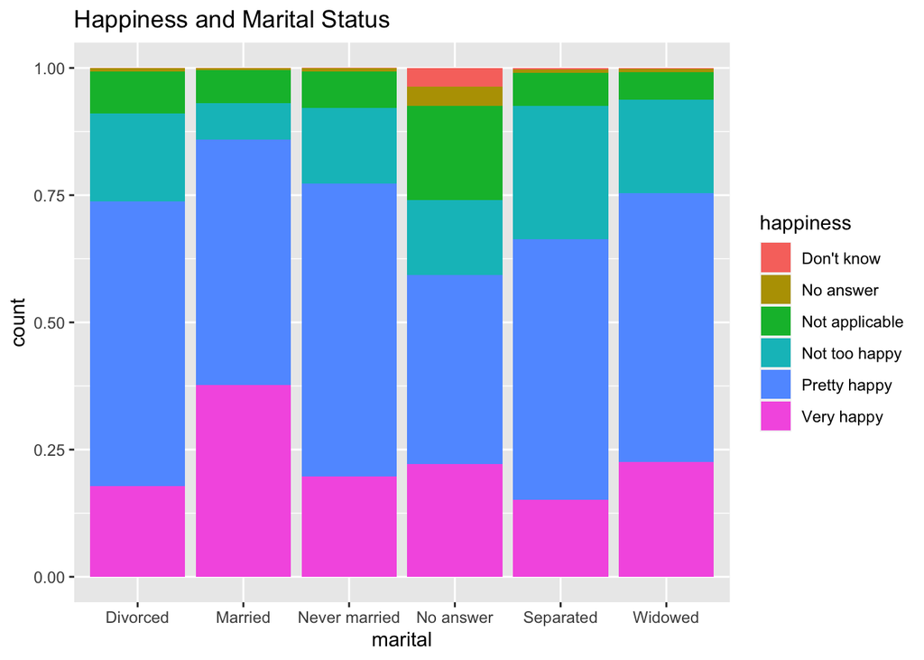

```r
dat%>%
  select(happiness, marital)%>%
  ggplot(aes(x=marital, fill=happiness)) + geom_bar(position='fill') + ggtitle("Happiness and Marital Status")
```

```r
dat%>%
  select(happiness, marital)%>%
  group_by(marital)%>%
  count(happiness)
```

```
## # A tibble: 36 x 3
## # Groups:   marital [6]
##    marital  happiness          n
##    <chr>    <chr>          <int>
##  1 Divorced Don't know         3
##  2 Divorced No answer         58
##  3 Divorced Not applicable   688
##  4 Divorced Not too happy   1450
##  5 Divorced Pretty happy    4683
##  6 Divorced Very happy      1497
##  7 Married  Don't know        12
##  8 Married  No answer        123
##  9 Married  Not applicable  2221
## 10 Married  Not too happy   2431
## # … with 26 more rows
```

4. It doesn’t seem like political party has much of an effect on happiness and marital status. For all political party identifications, married has the most happy respondents than the rest. Separated still had the least amount of happy respondents. For this I used the variables happiness, partyid, and marital.

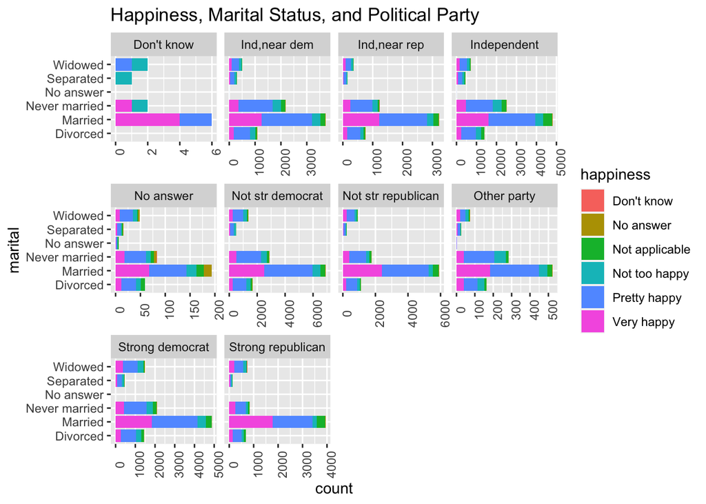

```r
ggplot(dat, aes(x=marital, fill=happiness)) + geom_bar() + facet_wrap(~partyid, scales="free_x") + coord_flip() + ggtitle("Happiness, Marital Status, and Political Party") + theme(axis.text.x = element_text(angle = 90))
```

```r
dat%>%
  select(happiness, partyid, marital)%>%
  group_by(partyid, marital)%>%
  count(happiness)
```

```
## # A tibble: 271 x 4
## # Groups:   partyid, marital [58]
##    partyid      marital       happiness          n
##    <chr>        <chr>         <chr>          <int>
##  1 Don't know   Married       Pretty happy       2
##  2 Don't know   Married       Very happy         4
##  3 Don't know   Never married Not too happy      1
##  4 Don't know   Never married Very happy         1
##  5 Don't know   Separated     Not too happy      1
##  6 Don't know   Widowed       Not too happy      1
##  7 Don't know   Widowed       Pretty happy       1
##  8 Ind,near dem Divorced      No answer          3
##  9 Ind,near dem Divorced      Not applicable    74
## 10 Ind,near dem Divorced      Not too happy    200
## # … with 261 more rows
```

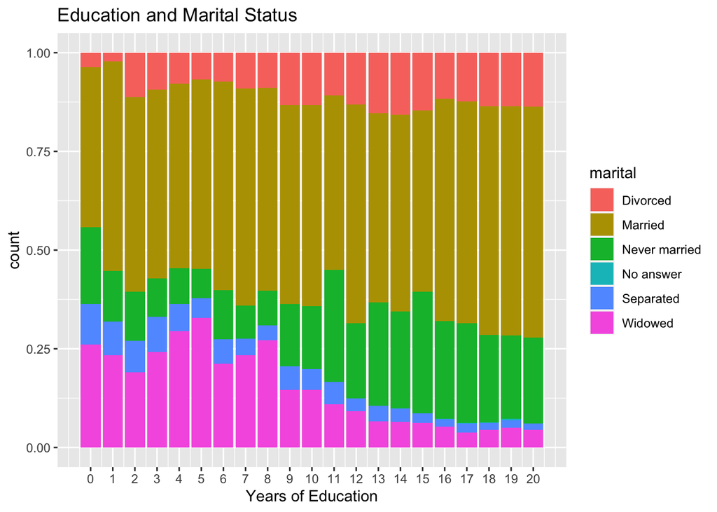

```r
dat%>%
  select(educ, marital)%>%
  filter(educ < 21)%>%
  ggplot(aes(x=educ, fill=marital)) + geom_bar(position='fill') + ggtitle("Education and Marital Status") + scale_x_continuous(breaks = 0:20, "Years of Education")
```

```r
dat%>%
  select(educ, marital)%>%
  filter(educ < 21)%>%
  group_by(marital)%>%
  count(educ)
```

```
## # A tibble: 113 x 3
## # Groups:   marital [6]
##    marital   educ     n
##    <chr>    <dbl> <int>
##  1 Divorced     0     6
##  2 Divorced     1     1
##  3 Divorced     2    17
##  4 Divorced     3    24
##  5 Divorced     4    25
##  6 Divorced     5    27
##  7 Divorced     6    61
##  8 Divorced     7    80
##  9 Divorced     8   245
## 10 Divorced     9   276
## # … with 103 more rows
```

6. My first question is “how does the respondent’s sex affect the happiness and marital status?” This question is similar to question 4, but replacing political party with gender. For this I used the variables happiness, sex, and marital.

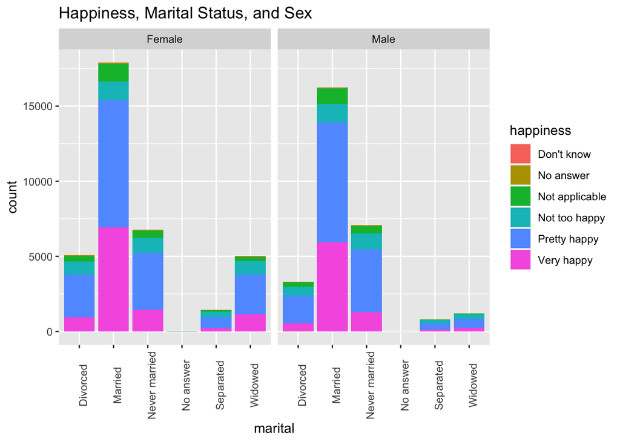

```r
ggplot(dat, aes(x=marital, fill=happiness)) + geom_bar() + facet_wrap(~sex, scales="free_x") + ggtitle("Happiness, Marital Status, and Sex") + theme(axis.text.x = element_text(angle = 90))
```

My second question is “how does the respondent’s age affect their happiness?” For this I used the variables happiness and age.

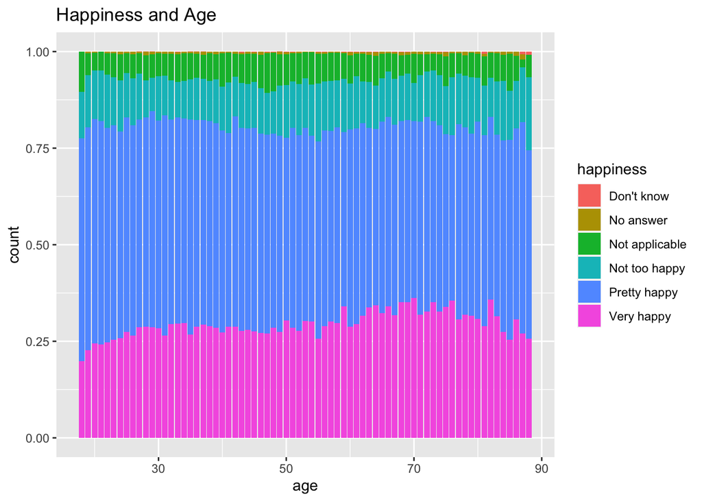

```r
dat%>%
  select(happiness, age)%>%
  filter(age > 17)%>%
  ggplot(aes(x=age, fill=happiness)) + geom_bar(position='fill') + ggtitle("Happiness and Age")
```